# RETRAUCI - Justification of the regional AIS severity cutoff (>= 4 vs >= 3)

2026-11-09

# Purpose

Each anatomical region is coded as a Yes/No severity variable from its regional AIS (0-6). The cutoff used so far was AIS >= 3; this document looks at how 30-day mortality changes with the regional AIS level in each region, to help decide whether AIS >= 3 or AIS >= 4 is a better definition of “severe”.

All years present in the registry export are used (no split by year), and patients are analysed region by region, without taking the injuries in the other regions into account.

# 1. Data

The cohort is built with the preprocessing code of `ultimate_validation_preprocessing.Rmd` (all code before the heading “Preprocessed cohort” is executed).

Analysis sample (complete cases)

| Sample | Patients | Deaths within 30 days | Mortality (%) |
| --- | --- | --- | --- |
| All years of the export | 16697 | 2080 | 12.5 |

# 2. Mortality by AIS level in each region

If AIS 4 is a better cutoff than AIS 3, mortality should rise clearly between 3 and 4 and not between 2 and 3. The table shows deaths / patients (30-day mortality) at each AIS level; the figure shows the same with 95% Wilson confidence intervals (levels with fewer than 10 patients are not drawn). Dotted lines mark the two candidate cutoffs.

30-day deaths / patients (mortality) by regional AIS level, all years

| Regional AIS | Head | Upper extremity | Thorax | Abdomen | Lower extremity (incl. pelvis) | External |
| --- | --- | --- | --- | --- | --- | --- |
| 0 | 330/6704 (4.9%) | 1635/13104 (12.5%) | 1178/7999 (14.7%) | 1627/11802 (13.8%) | 1414/9130 (15.5%) | 1959/15784 (12.4%) |
| 1 | 21/570 (3.7%) | 128/1293 (9.9%) | 31/327 (9.5%) | 7/153 (4.6%) | 42/490 (8.6%) | 68/705 (9.6%) |
| 2 | 95/1921 (4.9%) | 231/1798 (12.8%) | 139/1759 (7.9%) | 180/2178 (8.3%) | 259/3679 (7.0%) | 3/46 (6.5%) |
| 3 | 209/2966 (7.0%) | 69/451 (15.3%) | 354/4129 (8.6%) | 111/1547 (7.2%) | 173/2187 (7.9%) | 3/66 (4.5%) |
| 4 | 355/2172 (16.3%) | 17/50 (34.0%) | 227/1761 (12.9%) | 97/786 (12.3%) | 79/860 (9.2%) | 7/33 (21.2%) |
| 5 | 1015/2305 (44.0%) | 0/1 (0.0%) | 144/709 (20.3%) | 56/229 (24.5%) | 113/351 (32.2%) | 36/59 (61.0%) |
| 6 | 55/59 (93.2%) | - | 7/13 (53.8%) | 2/2 (100.0%) | - | 4/4 (100.0%) |

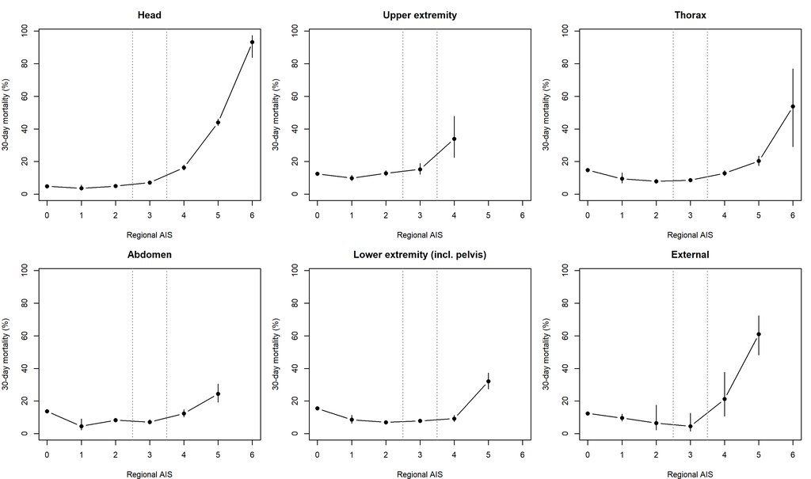

30-day mortality by regional AIS level (all years, same y axis in all panels). Dotted lines: candidate cutoffs >= 3 (between 2 and 3) and >= 4 (between 3 and 4).

## Mortality by AIS level, alone or together with another region

Same figure, now with six lines per panel. In each panel (region) the patients injured in that region (AIS 1-6) are split in these groups:

- **Only this region**: no other region has any injury (AIS 0 in the other five).
- **+ Head, + Upper extremity, + Thorax, + Abdomen, + Lower extremity,
  - External**: the other region named has an injury (AIS >= 1), whatever its severity and whatever happens in the remaining regions.

The “+” groups overlap: a patient with injuries in the region plus head and thorax appears in both the “+ Head” and the “+ Thorax” lines. Colours are the same for the same region in every panel. Levels with fewer than 10 patients in a group are not drawn, the lines are shifted slightly horizontally so that the confidence intervals do not overlap, and the y axis is the same in all panels. AIS 0 is not drawn because the lines refer to patients injured in the region.

Patients injured in each region (AIS 1-6) in each group (the groups with ‘+’ overlap; all years)

| Region | Injured in this region | Only this region | + Head | + Upper extremity | + Thorax | + Abdomen | + Lower extremity (incl. pelvis) | + External |
| --- | --- | --- | --- | --- | --- | --- | --- | --- |
| Head | 9993 | 3396 | - | 2752 | 4265 | 1818 | 3715 | 416 |
| Upper extremity | 3593 | 110 | 2752 | - | 1859 | 874 | 1797 | 230 |
| Thorax | 8698 | 940 | 4265 | 1859 | - | 3521 | 5094 | 426 |
| Abdomen | 4895 | 484 | 1818 | 874 | 3521 | - | 2952 | 237 |
| Lower extremity (incl. pelvis) | 7567 | 678 | 3715 | 1797 | 5094 | 2952 | - | 397 |
| External | 913 | 157 | 416 | 230 | 426 | 237 | 397 | - |

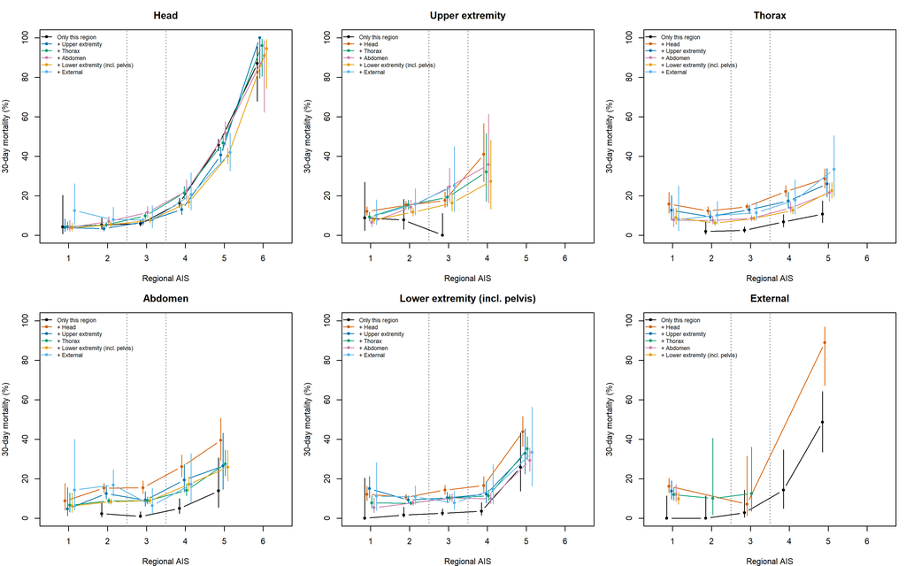

30-day mortality by regional AIS level, with the injury alone or together with each other region (all years, same y axis in all panels). Dotted lines: candidate cutoffs >= 3 (between 2 and 3) and >= 4 (between 3 and 4).

## The same figure, one graph per region

The six panels above are repeated here one by one, larger. Each graph uses its own y axis (to see the detail of each region); set `use_common_ylim <- TRUE` in the next chunk to use the same axis in all of them.

### Head

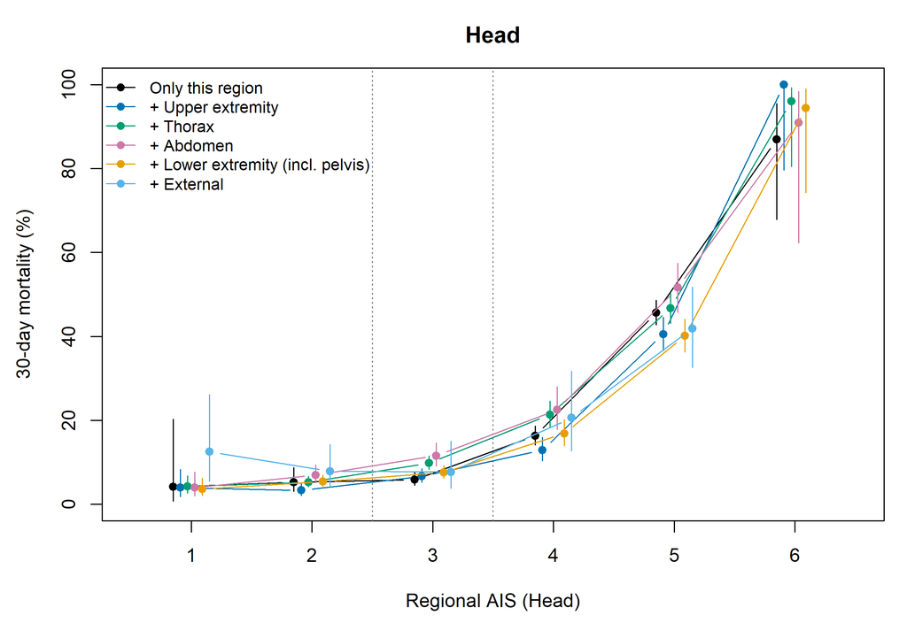

Head: 30-day mortality by AIS level, alone or together with another region. Dotted lines: cutoffs >= 3 and >= 4.

### Upper extremity

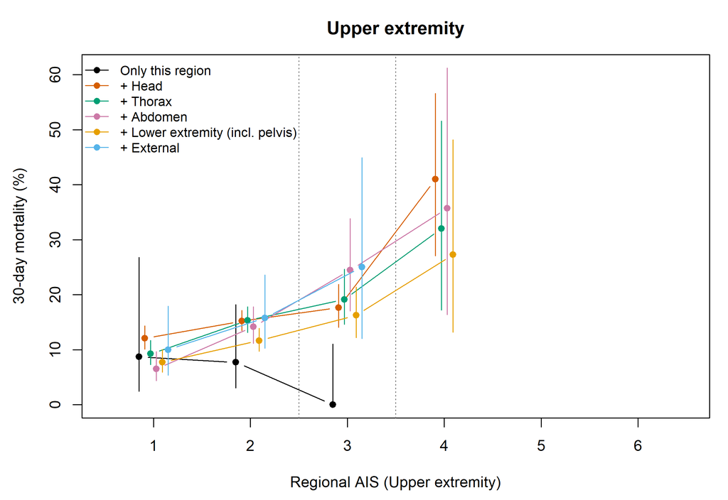

Upper extremity: 30-day mortality by AIS level, alone or together with another region. Dotted lines: cutoffs >= 3 and >= 4.

### Thorax

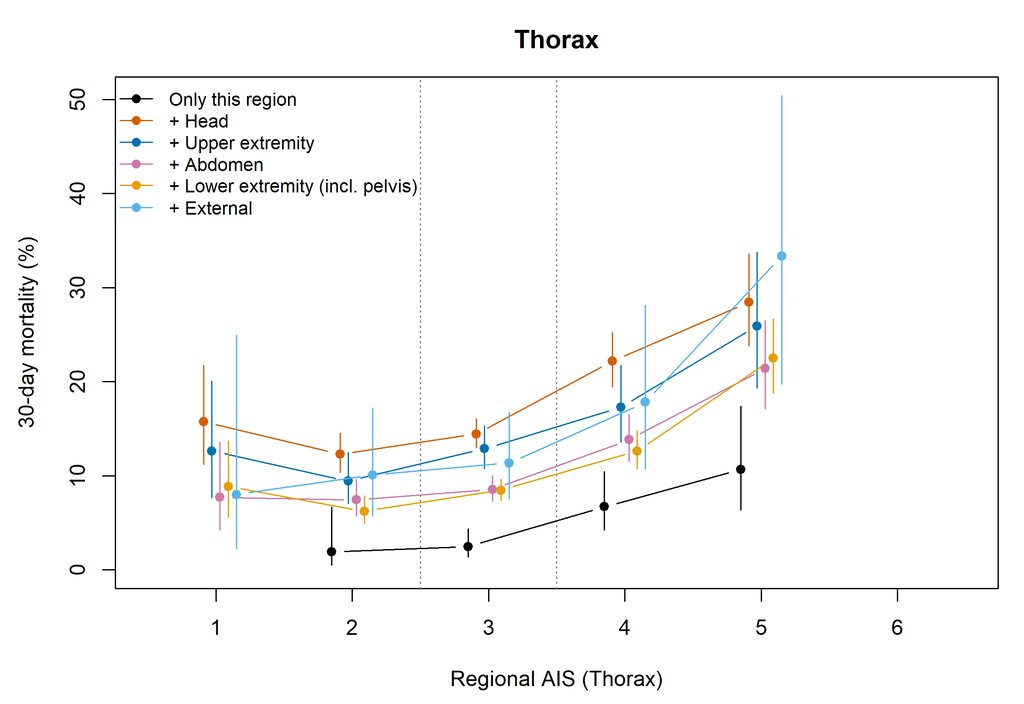

Thorax: 30-day mortality by AIS level, alone or together with another region. Dotted lines: cutoffs >= 3 and >= 4.

### Abdomen

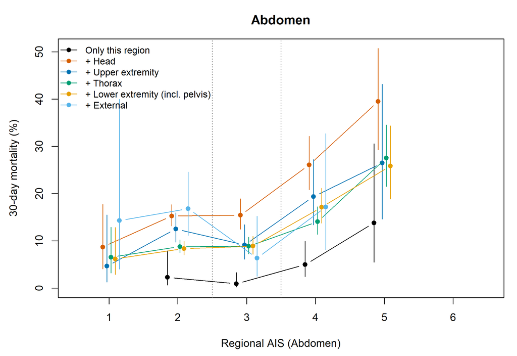

Abdomen: 30-day mortality by AIS level, alone or together with another region. Dotted lines: cutoffs >= 3 and >= 4.

### Lower extremity (incl. pelvis)

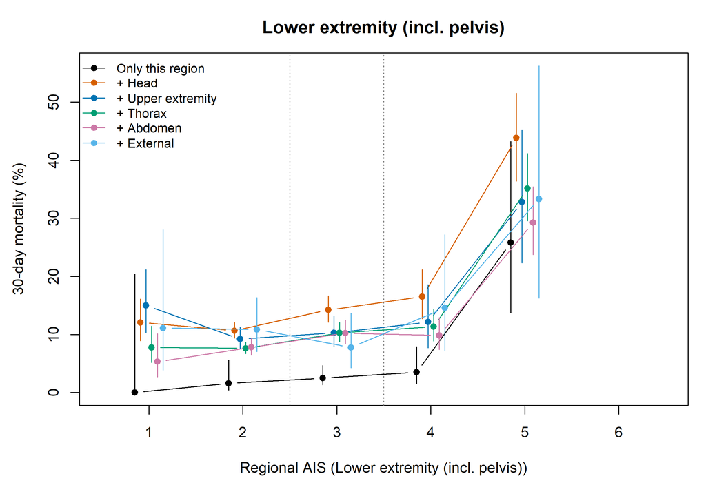

Lower extremity: 30-day mortality by AIS level, alone or together with another region. Dotted lines: cutoffs >= 3 and >= 4.

### External

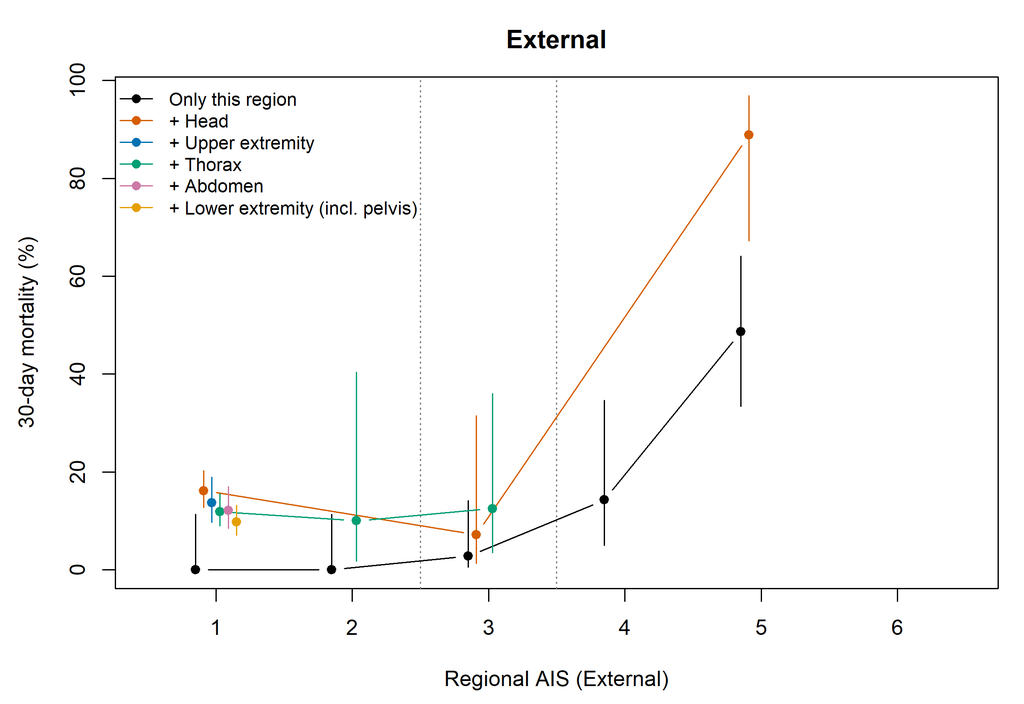

External: 30-day mortality by AIS level, alone or together with another region. Dotted lines: cutoffs >= 3 and >= 4.

## By age: under 65 and 65 or more

The six-panel figure is repeated twice: first for patients younger than 65 years and then for patients aged 65 or more (age in years, from the registry). The groups of each panel are the same as above. Both figures use the same y axis, so that they can be compared directly. Patients with unknown age are left out.

| Age group | Patients | Deaths within 30 days | Mortality (%) |
| --- | --- | --- | --- |
| Younger than 65 years | 11391 | 863 | 7.6 |
| Aged 65 years or more | 4085 | 1060 | 25.9 |

### Patients younger than 65 years

Younger than 65 years: patients injured in each region (AIS 1-6) in each group (groups with ‘+’ overlap)

| Region | Injured in this region | Only this region | + Head | + Upper extremity | + Thorax | + Abdomen | + Lower extremity (incl. pelvis) | + External |
| --- | --- | --- | --- | --- | --- | --- | --- | --- |
| Head | 6379 | 1769 | - | 1974 | 2979 | 1358 | 2637 | 310 |
| Upper extremity | 2624 | 86 | 1974 | - | 1374 | 679 | 1345 | 176 |
| Thorax | 6181 | 586 | 2979 | 1374 | - | 2653 | 3746 | 322 |
| Abdomen | 3761 | 411 | 1358 | 679 | 2653 | - | 2284 | 182 |
| Lower extremity (incl. pelvis) | 5625 | 546 | 2637 | 1345 | 3746 | 2284 | - | 310 |
| External | 684 | 108 | 310 | 176 | 322 | 182 | 310 | - |

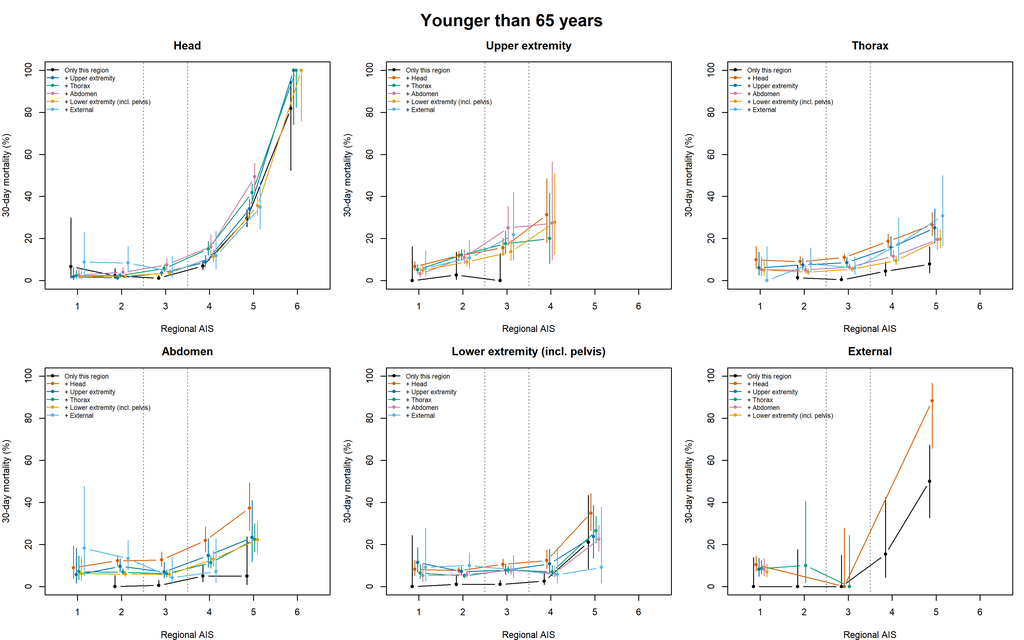

Patients younger than 65 years: 30-day mortality by regional AIS level, alone or together with another region (same y axis as the 65-or-more figure). Dotted lines: cutoffs >= 3 and >= 4.

### Patients aged 65 years or more

Aged 65 years or more: patients injured in each region (AIS 1-6) in each group (groups with ‘+’ overlap)

| Region | Injured in this region | Only this region | + Head | + Upper extremity | + Thorax | + Abdomen | + Lower extremity (incl. pelvis) | + External |
| --- | --- | --- | --- | --- | --- | --- | --- | --- |
| Head | 2854 | 1349 | - | 570 | 974 | 336 | 809 | 79 |
| Upper extremity | 714 | 18 | 570 | - | 350 | 136 | 332 | 34 |
| Thorax | 1869 | 260 | 974 | 350 | - | 618 | 988 | 75 |
| Abdomen | 812 | 50 | 336 | 136 | 618 | - | 471 | 38 |
| Lower extremity (incl. pelvis) | 1429 | 92 | 809 | 332 | 988 | 471 | - | 62 |
| External | 172 | 40 | 79 | 34 | 75 | 38 | 62 | - |

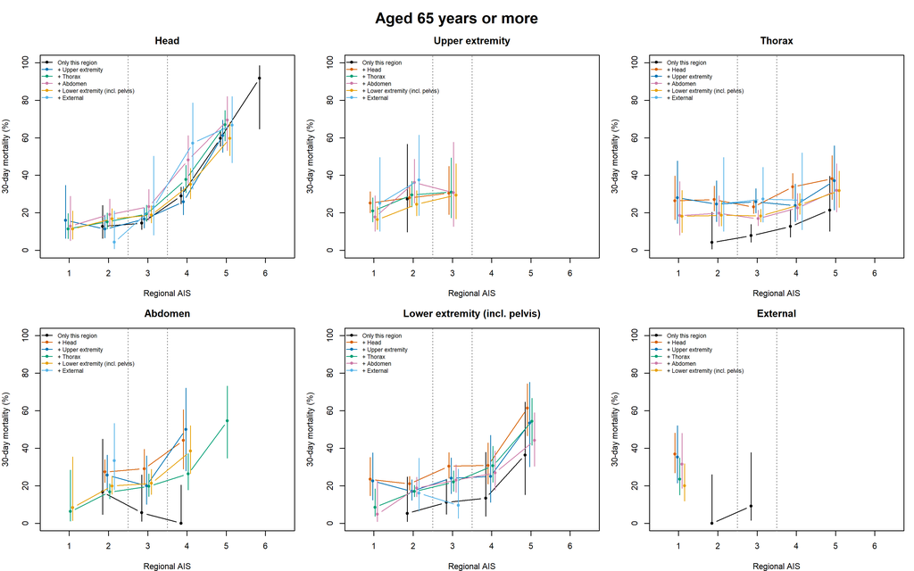

Patients aged 65 years or more: 30-day mortality by regional AIS level, alone or together with another region (same y axis as the under-65 figure). Dotted lines: cutoffs >= 3 and >= 4.

# 3. Mortality by number of regions and by highest AIS (any region)

Here the region is not taken into account: each patient is described by how many of the six regions are injured, and by the highest AIS among the six regions. All years and all patients are used. A region counts as injured when its AIS is 1 or more. The six regions are head, upper extremity, thorax, abdomen, lower extremity (including pelvis) and external. Patients with AIS 0 in all six regions (no injury recorded in any of them) are shown in the tables but not in the figures; their meaning is doubtful, since an empty AIS is coded as 0.

## 3.1 Mortality by number of injured regions

30-day mortality by number of injured regions (AIS >= 1), all years

| Injured regions | Patients | Deaths within 30 days | Mortality (%) | 95% CI (Wilson) |
| --- | --- | --- | --- | --- |
| 0 | 139 | 35 | 25.2 | 18.7-33.0 |
| 1 | 5765 | 891 | 15.5 | 14.5-16.4 |
| 2 | 4969 | 430 | 8.7 | 7.9-9.5 |
| 3 | 3769 | 397 | 10.5 | 9.6-11.6 |
| 4 | 1657 | 249 | 15.0 | 13.4-16.8 |
| 5 | 367 | 69 | 18.8 | 15.1-23.1 |
| 6 | 31 | 9 | 29.0 | 16.1-46.6 |

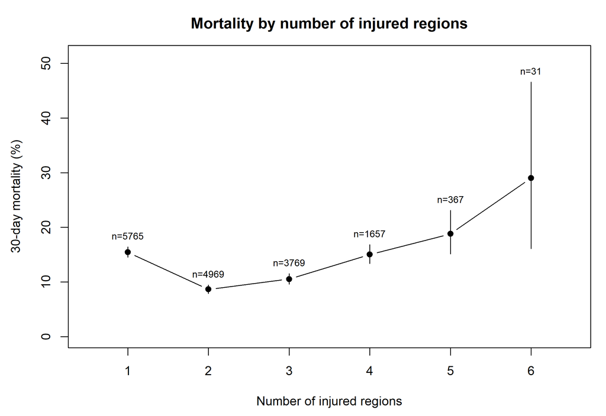

30-day mortality by number of injured regions (AIS >= 1), whichever they are. Bars: 95% Wilson confidence intervals; groups with fewer than 10 patients are not drawn.

## 3.2 Mortality by the highest AIS

The highest AIS is the maximum of the six regional AIS values of each patient, whichever region it belongs to.

30-day mortality by the highest regional AIS of the patient, all years

| Highest AIS | Patients | Deaths within 30 days | Mortality (%) | 95% CI (Wilson) |
| --- | --- | --- | --- | --- |
| 0 | 139 | 35 | 25.2 | 18.7-33.0 |
| 1 | 149 | 3 | 2.0 | 0.7-5.8 |
| 2 | 1660 | 41 | 2.5 | 1.8-3.3 |
| 3 | 6506 | 216 | 3.3 | 2.9-3.8 |
| 4 | 4705 | 474 | 10.1 | 9.2-11.0 |
| 5 | 3461 | 1244 | 35.9 | 34.4-37.6 |
| 6 | 77 | 67 | 87.0 | 77.7-92.8 |

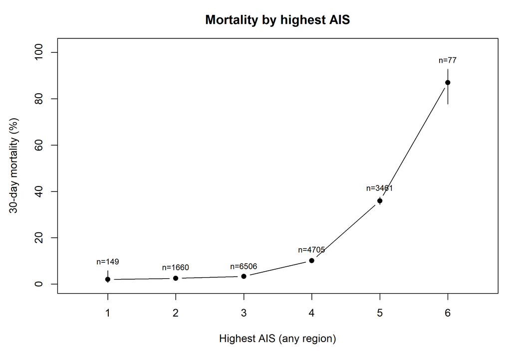

30-day mortality by the highest regional AIS of the patient, whichever region it belongs to. Bars: 95% Wilson confidence intervals; groups with fewer than 10 patients are not drawn.